# 市场观察

2017/09/05

## A、指数估值

### (a1)动态市盈率、市净率

核心指数成分股近18个月的动态市盈率及动态市净率中位数走势如下图所示：

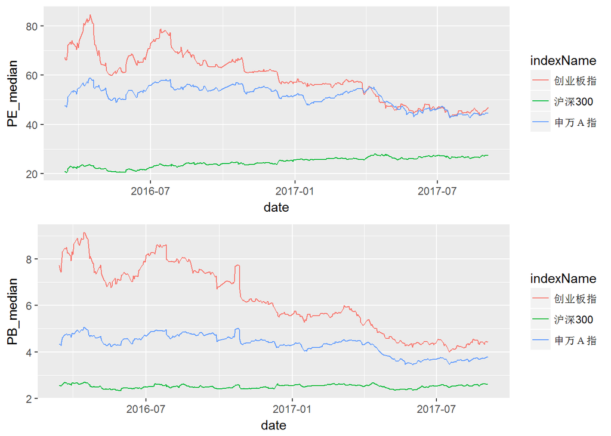

### (a2)动态市盈率、市净率百分位

核心指数近18个月的动态市盈率百分位及动态市净率百分位走势如下图所示：

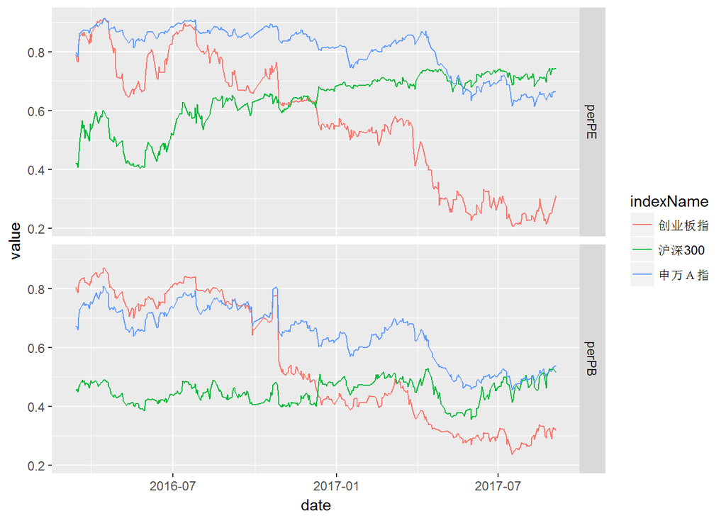

### (a3)指数估值概览

纳入观察的指数最新的估值情况如下表，根据市盈率和市净率分位数均值降序排列。

| 指数代码 | 指数简称 | 日期 | 动态市盈率 | 市盈率百分位 | 动态市净率 | 市净率百分位 |
| --- | --- | --- | --- | --- | --- | --- |
| EI000819 | 有色金属 | 2017-09-04 | 63.1 | 85% | 3.8 | 78% |
| EI000979 | 大宗商品 | 2017-09-04 | 35.8 | 66% | 2.8 | 63% |
| EI000300 | 沪深300 | 2017-09-04 | 27.6 | 75% | 2.6 | 51% |
| EI801003 | 申万Ａ指 | 2017-09-04 | 44.7 | 67% | 3.8 | 54% |
| EI399330 | 深证100 | 2017-09-04 | 31.3 | 63% | 3.6 | 48% |
| EI399005 | 中小板指P | 2017-09-04 | 40.4 | 62% | 4.5 | 41% |
| EI399959 | 军工指数 | 2017-09-04 | 76.9 | 50% | 3.9 | 46% |
| EI000934 | 中证金融 | 2017-09-04 | 19.9 | 69% | 1.9 | 26% |
| EI000922 | 中证红利 | 2017-09-04 | 17.6 | 58% | 1.8 | 34% |
| EI000998 | 中证TMT | 2017-09-04 | 44.9 | 54% | 3.7 | 33% |
| EI000905 | 中证500 | 2017-09-04 | 34.9 | 43% | 3.0 | 37% |
| EI000016 | 上证50 | 2017-09-04 | 17.2 | 55% | 1.6 | 16% |
| EI000932 | 中证消费 | 2017-09-04 | 29.8 | 30% | 4.0 | 38% |
| EI399006 | 创业板指 | 2017-09-04 | 46.9 | 31% | 4.4 | 32% |
| EI000827 | 中证环保 | 2017-09-04 | 33.5 | 18% | 3.1 | 31% |
| EI000933 | 中证医药 | 2017-09-04 | 31.2 | 13% | 3.6 | 2% |

### (a4)另类估值

我国10年期国债收益率、金银比价、金油比价，2000年以来的历史百分位如下图所示：

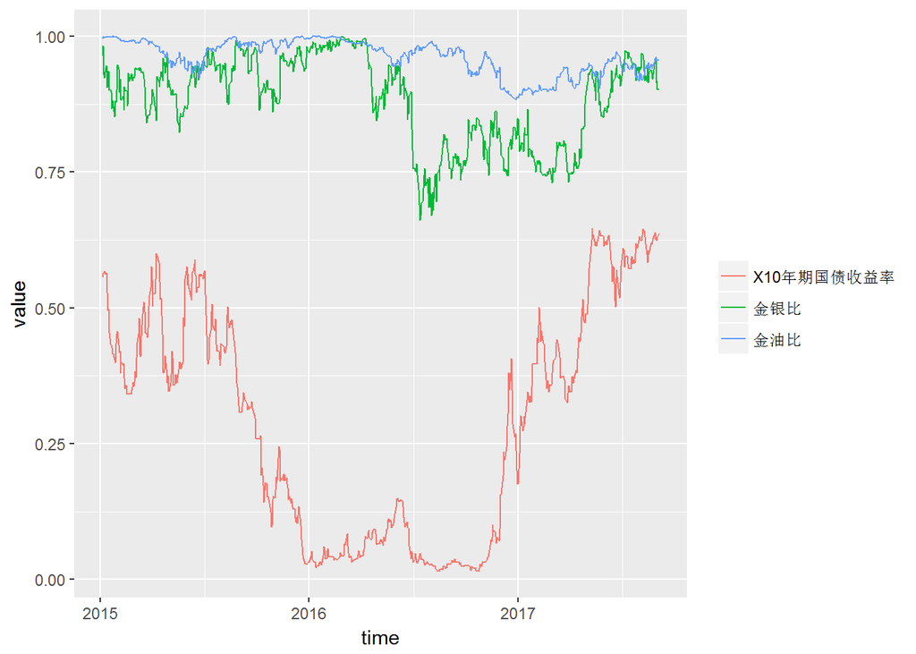

## B、基差及市场情绪

### (b1)基差走势

三大股指期货合约基差走势如下图，其中当月合约和次月合约年化基差百分比波动较大，仅展示合约基差百分比，当季合约和次季合约展示基差年化百分比：

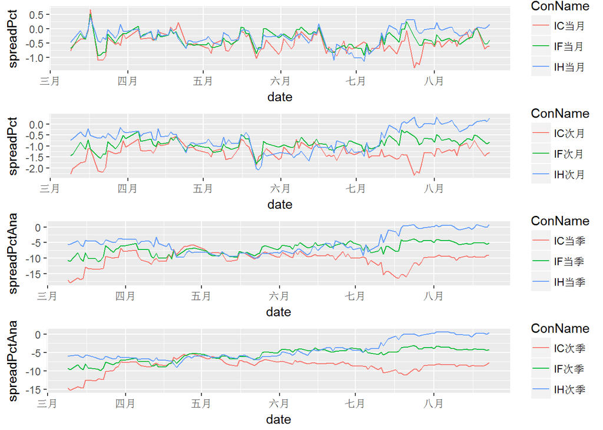

### (b2)基差概况

三大股指期货连续合约基差概况如下表，近月合约临近到期日，年化基差百分比数据波动较大：

| 日期 | 合约代码 | 合约收盘价 | 指数收盘价 | 基差 | 基差百分比 | 年化基差百分比 |
| --- | --- | --- | --- | --- | --- | --- |
| 2017-08-23 | IC1709 | 6285.2 | 6322.8 | -37.6 | -0.6% | -9.9% |
| 2017-08-23 | IC1710 | 6241.0 | 6322.8 | -81.8 | -1.3% | -8.4% |
| 2017-08-23 | IC1712 | 6149.2 | 6322.8 | -173.6 | -2.7% | -9.1% |
| 2017-08-23 | IC1803 | 6052.4 | 6322.8 | -270.4 | -4.3% | -7.7% |
| 2017-08-23 | IF1709 | 3741.6 | 3756.1 | -14.5 | -0.4% | -6.3% |
| 2017-08-23 | IF1710 | 3725.4 | 3756.1 | -30.7 | -0.8% | -5.3% |
| 2017-08-23 | IF1712 | 3698.0 | 3756.1 | -58.1 | -1.5% | -5.0% |
| 2017-08-23 | IF1803 | 3670.0 | 3756.1 | -86.1 | -2.3% | -4.1% |
| 2017-08-23 | IH1709 | 2664.2 | 2659.8 | 4.4 | 0.2% | 2.7% |
| 2017-08-23 | IH1710 | 2667.2 | 2659.8 | 7.4 | 0.3% | 1.8% |
| 2017-08-23 | IH1712 | 2667.2 | 2659.8 | 7.4 | 0.3% | 0.9% |
| 2017-08-23 | IH1803 | 2666.8 | 2659.8 | 7.0 | 0.3% | 0.5% |

### (b3)市场情绪(provided by han.qian)

市场情绪记录近60天每天自然涨跌停(剔除一字板)、创60日新高新低、多头排列空头排列(均线组合5,30,60,120)的股票数。

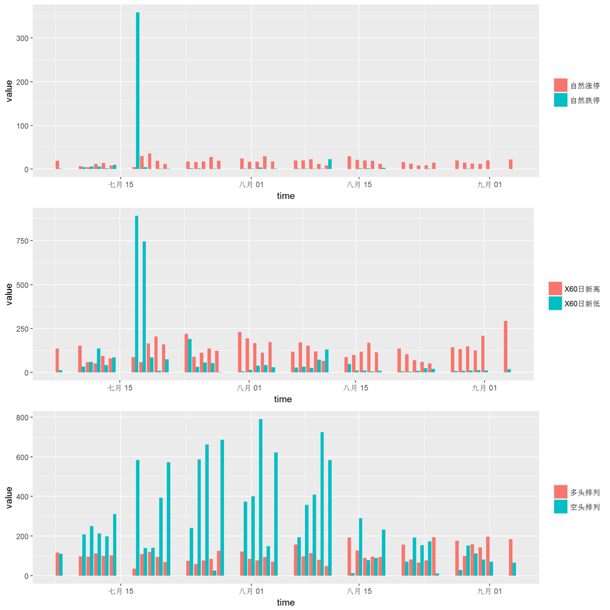

## C、套利和事件

### (c1)复牌股票套利

近两天复牌股票套利情况如下表：

[1] “No Arbitrage!”

### (c2)解禁

解禁分成两个部分，定增解禁和IPO解禁，涨跌幅记录是过去十个交易日的股票涨跌幅和对应行业指数涨跌幅。伴随着去年下半年IPO逐步正常化，今后IPO解禁给市场造成的抛压会持续存在，所以纳入观察。近期定增解禁的股票情况如下表。

| 股票代码 | 股票简称 | 解禁日 | 解禁数量 | 解禁百分比 | 区间涨跌幅 | 所属行业指数 | 行业指数涨跌幅 |
| --- | --- | --- | --- | --- | --- | --- | --- |
| EQ002505 | 大康农业 | 2017-09-06 | 39.38 | 255% | 0.0% | 申万农林牧渔 | 2.2% |
| EQ002446 | 盛路通信 | 2017-09-06 | 1.11 | 34% | -2.6% | 申万通信 | 1.3% |
| EQ600221 | 海航控股 | 2017-09-06 | 46.24 | 39% | 0.9% | 申万交通运输 | 0.4% |
| EQ002602 | 世纪华通 | 2017-09-06 | 4.39 | 75% | -3.3% | 申万传媒 | 1.6% |
| EQ002747 | 埃斯顿 | 2017-09-08 | 0.98 | 55% | 10.4% | 申万机械设备 | 2.1% |
| EQ300108 | 吉药控股 | 2017-09-11 | 3.05 | 93% | 4.7% | 申万医药生物 | 0.4% |
| EQ600485 | 信威集团 | 2017-09-11 | 12.92 | 79% | 0.0% | 申万通信 | 1.3% |
| EQ600155 | 宝硕股份 | 2017-09-11 | 7.16 | 174% | 11.0% | 申万非银金融 | 6.4% |
| EQ300282 | 汇冠股份 | 2017-09-12 | 0.40 | 24% | 0.6% | 申万电子 | 4.7% |
| EQ002197 | 证通电子 | 2017-09-13 | 0.94 | 28% | 6.5% | 申万计算机 | 4.4% |
| EQ000837 | 秦川机床 | 2017-09-15 | 2.12 | 44% | -0.1% | 申万机械设备 | 2.1% |
| EQ000928 | 中钢国际 | 2017-09-18 | 4.13 | 56% | -2.0% | 申万建筑装饰 | 0.9% |

近期IPO解禁的股票情况如下表。

| 股票代码 | 股票简称 | 解禁日 | 解禁数量 | 解禁百分比 | 区间涨跌幅 | 所属行业指数 | 行业指数涨跌幅 | 上市日 |
| --- | --- | --- | --- | --- | --- | --- | --- | --- |
| EQ603843 | 正平股份 | 2017-09-08 | 0.93 | 93% | -1.8% | 申万建筑装饰 | 0.9% | 2016-09-05 |
| EQ300543 | 朗科智能 | 2017-09-08 | 0.13 | 42% | 5.2% | 申万电子 | 4.7% | 2016-09-08 |
| EQ603188 | 亚邦股份 | 2017-09-11 | 1.97 | 52% | 7.0% | 申万化工 | 1.7% | 2014-09-09 |
| EQ300108 | 吉药控股 | 2017-09-11 | 3.05 | 93% | 4.7% | 申万医药生物 | 0.4% | 2010-08-25 |
| EQ601163 | 三角轮胎 | 2017-09-11 | 0.80 | 40% | 0.7% | 申万化工 | 1.7% | 2016-09-09 |
| EQ300396 | 迪瑞医疗 | 2017-09-11 | 1.07 | 229% | 5.6% | 申万医药生物 | 0.4% | 2014-09-10 |
| EQ300397 | 天和防务 | 2017-09-11 | 1.33 | 129% | -2.6% | 申万国防军工 | -0.4% | 2014-09-10 |
| EQ300395 | 菲利华 | 2017-09-11 | 0.72 | 34% | 0.8% | 申万有色金属 | 8.4% | 2014-09-10 |
| EQ300392 | 腾信股份 | 2017-09-11 | 2.18 | 133% | -0.9% | 申万传媒 | 1.6% | 2014-09-10 |
| EQ603393 | 新天然气 | 2017-09-12 | 0.56 | 139% | 1.6% | 申万公用事业 | 1.0% | 2016-09-12 |
| EQ002729 | 好利来 | 2017-09-12 | 0.49 | 277% | 0.6% | 申万电子 | 4.7% | 2014-09-12 |
| EQ300393 | 中来股份 | 2017-09-12 | 1.02 | 133% | -4.5% | 申万电气设备 | 1.9% | 2014-09-12 |
| EQ300534 | 陇神戎发 | 2017-09-13 | 1.32 | 174% | 1.9% | 申万医药生物 | 0.4% | 2016-09-13 |
| EQ300541 | 先进数通 | 2017-09-13 | 0.21 | 69% | 14.6% | 申万计算机 | 4.4% | 2016-09-13 |
| EQ603067 | 振华股份 | 2017-09-13 | 0.56 | 102% | 0.1% | 申万化工 | 1.7% | 2016-09-13 |
| EQ002812 | 创新股份 | 2017-09-14 | 0.29 | 88% | 10.2% | 申万轻工制造 | 1.8% | 2016-09-14 |
| EQ603189 | 网达软件 | 2017-09-14 | 0.55 | 99% | 8.6% | 申万计算机 | 4.4% | 2016-09-14 |